# COVID-19 Situation Report

[UnlikelyVolcano (David Azizi)](https://unlikelyvolcano.com)

This report was last updated on 2020-03-23. Data courtesy of [JHU CSSE](https://systems.jhu.edu/research/public-health/ncov/). See also the [COVID Tracking Project](https://covidtracking.com/).

# Overview

**Cases:** 335,955

**Active:** 223,619 (66.6%)

**Recovered:** 97,704 (29.1%)

**Deaths:** 14,632 (4.4%)

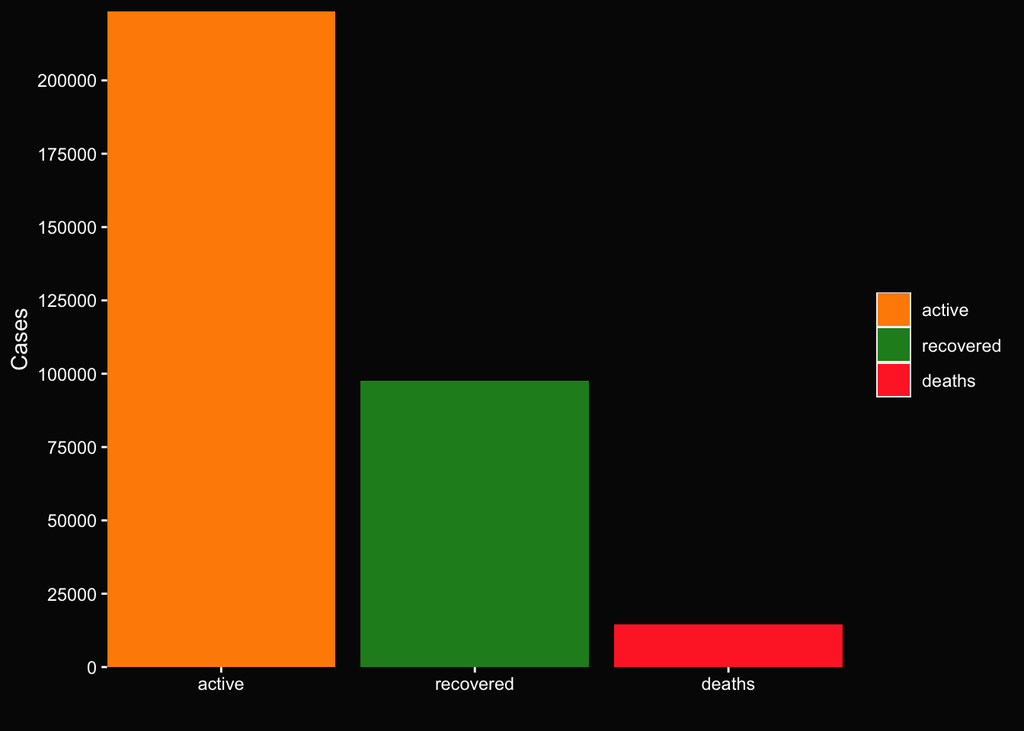

# Case Map

## United States

[interactive chart not shown]

## Global

[interactive chart not shown]

# Cumulative Cases

## United States

### Linear Scale

The cumulative number of cases doesn’t tell us much – it’s not possible for this number to go down. We can see that the growth seems to be accelerating, but we will look closer in the next chart.

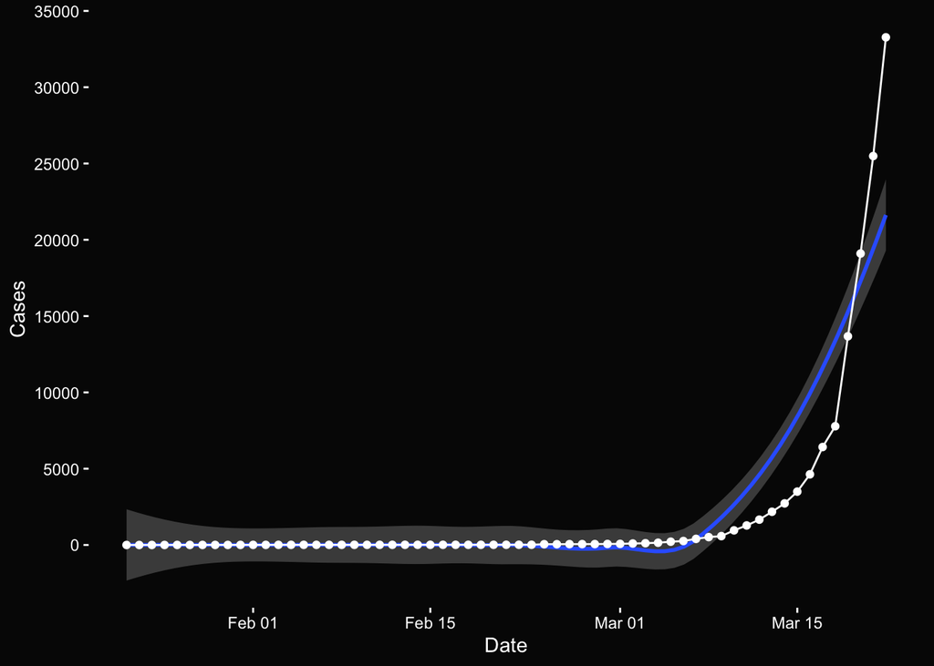

### Log Scale

An OLS fit to the logged values shows how closely the pandemic mimics an exponential curve. (All pandemics are modeled as a logistic function since there is a ceiling to the number of infected individuals, but in the growth phase, we can model them as exponential.) If the rate of growth were slowing, points would begin to appear below the fit line. The second line is fit only only to March, once testing ramped up in the US – note the narrower confidence bands.

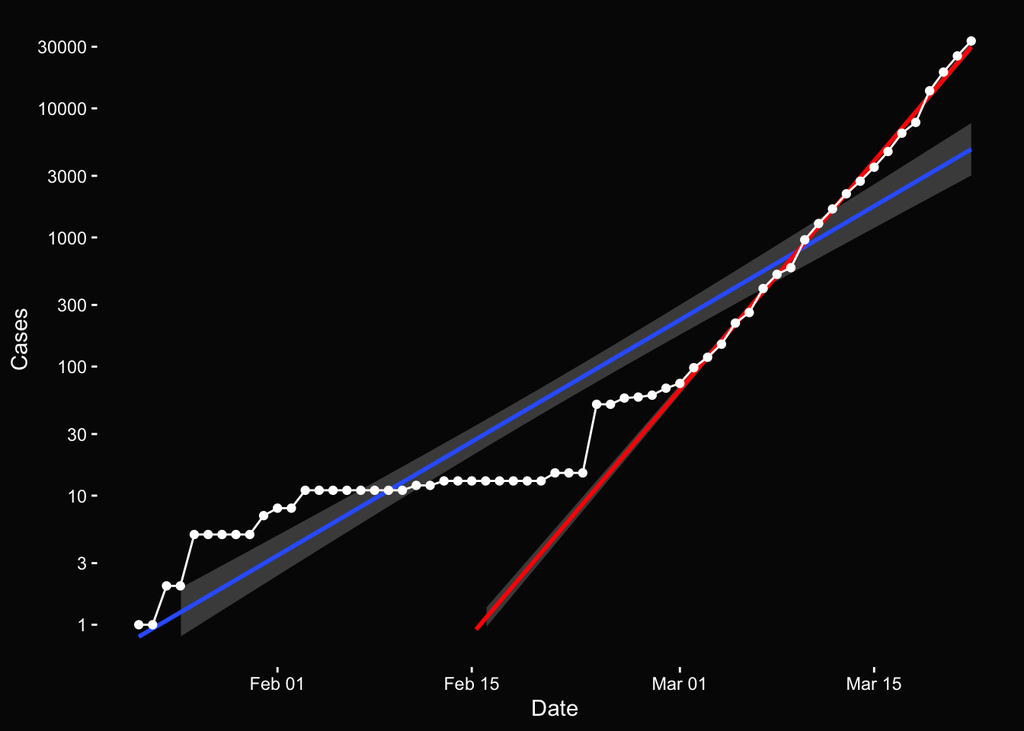

## Global

### Linear Scale

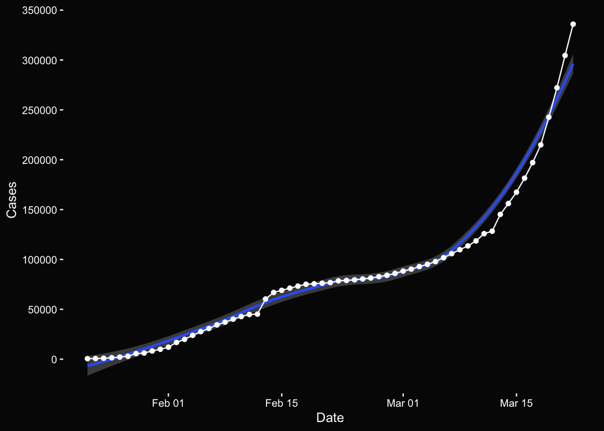

### Log Scale

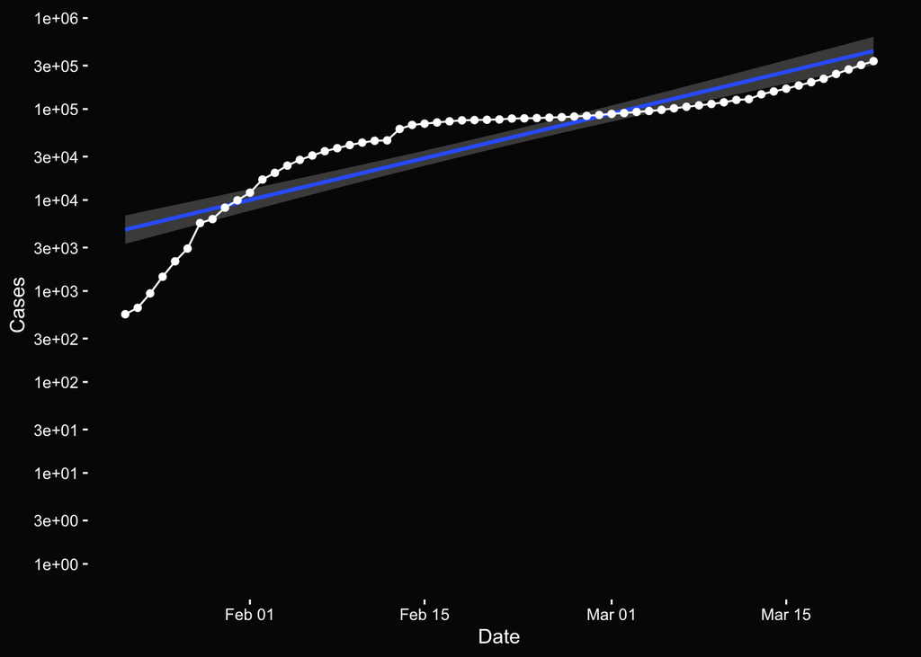

# Growth Rate

## United States

### New Cases by Day

This is the famed curve that needs to be flattened so we don’t overwhelm our medical capacity on the first wave of the pandemic. As you can see, we are still climbing.

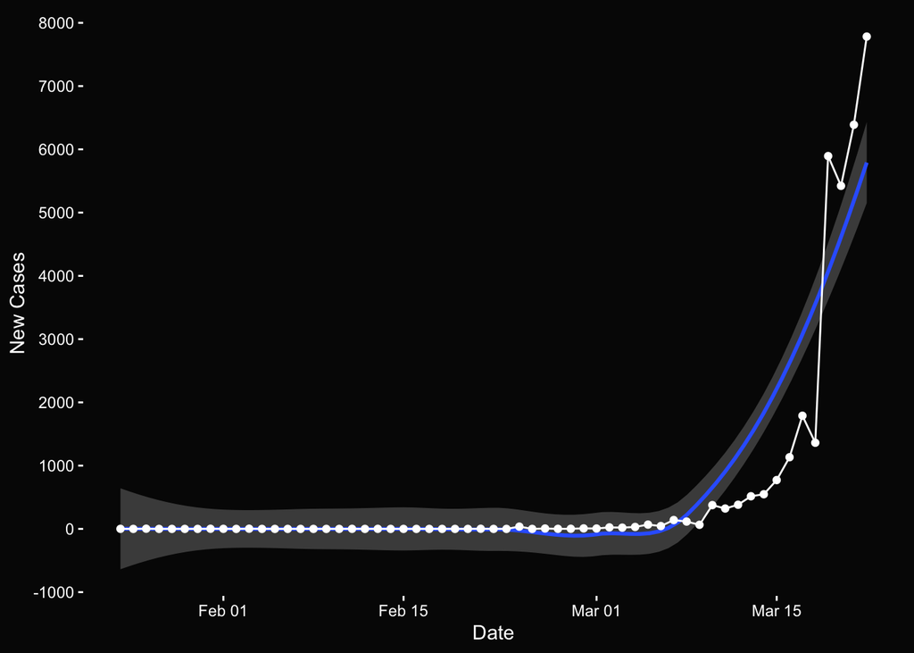

### Rate of Change in New Cases

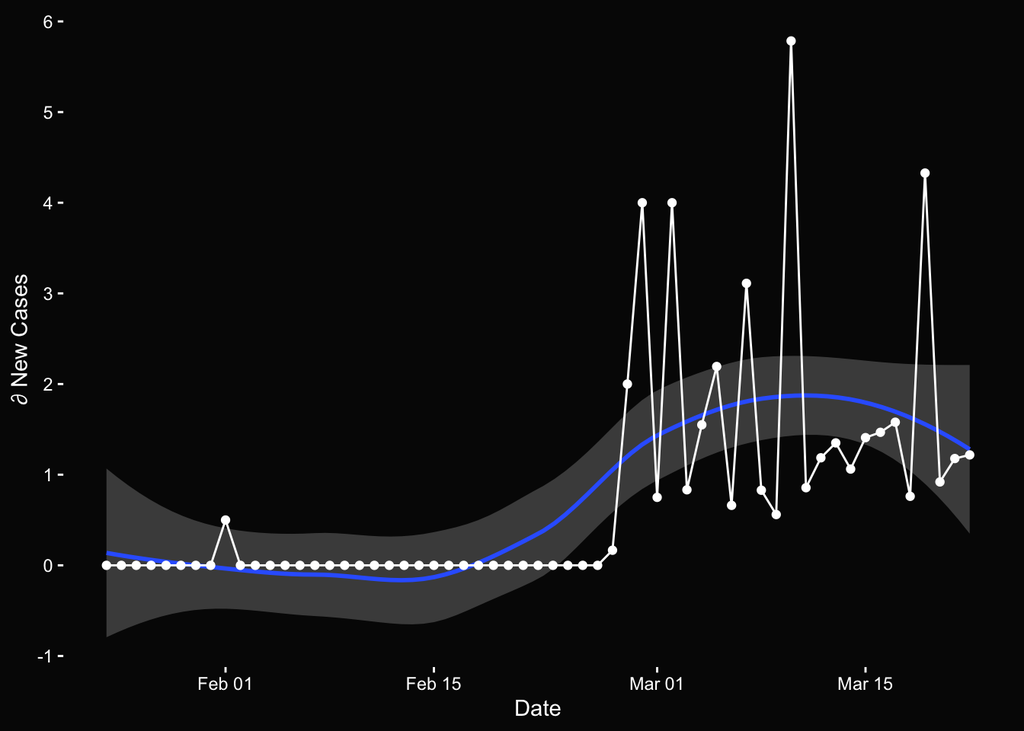

## Global

### New Cases by Day

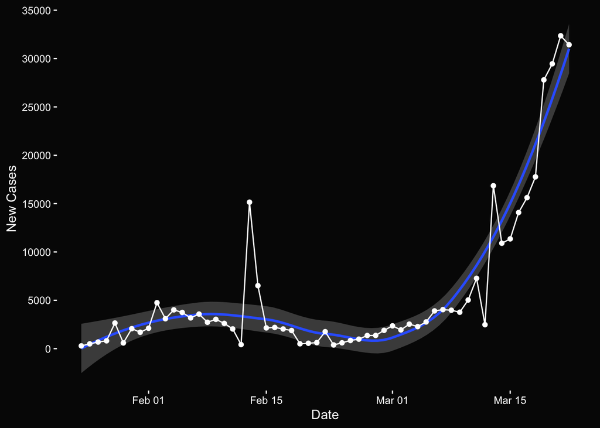

### Rate of Change in New Cases

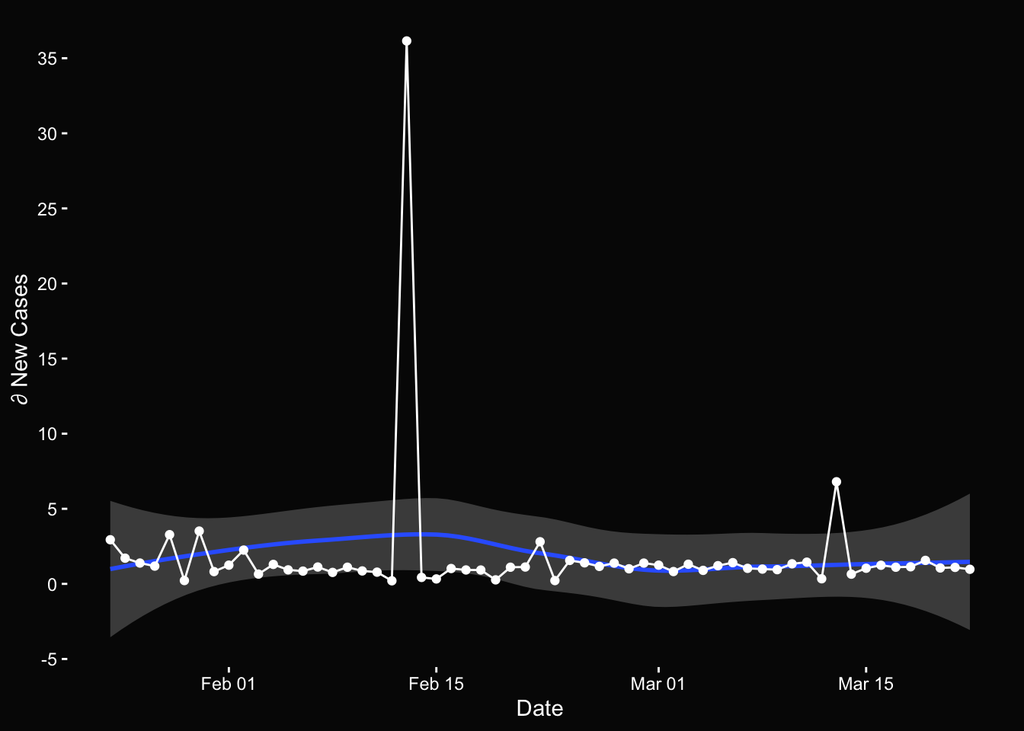

# Table

## United States

| Date | Cases | ∂ Cases | New Cases | ∂ New Cases |
| --- | --- | --- | --- | --- |
| 2020-03-01 | 74 | 1.088 | 6 | 0.750 |
| 2020-03-02 | 98 | 1.324 | 24 | 4.000 |
| 2020-03-03 | 118 | 1.204 | 20 | 0.833 |
| 2020-03-04 | 149 | 1.263 | 31 | 1.550 |
| 2020-03-05 | 217 | 1.456 | 68 | 2.194 |
| 2020-03-06 | 262 | 1.207 | 45 | 0.662 |
| 2020-03-07 | 402 | 1.534 | 140 | 3.111 |
| 2020-03-08 | 518 | 1.289 | 116 | 0.829 |
| 2020-03-09 | 583 | 1.125 | 65 | 0.560 |
| 2020-03-10 | 959 | 1.645 | 376 | 5.785 |
| 2020-03-11 | 1,281 | 1.336 | 322 | 0.856 |
| 2020-03-12 | 1,663 | 1.298 | 382 | 1.186 |
| 2020-03-13 | 2,179 | 1.310 | 516 | 1.351 |
| 2020-03-14 | 2,727 | 1.251 | 548 | 1.062 |
| 2020-03-15 | 3,499 | 1.283 | 772 | 1.409 |
| 2020-03-16 | 4,632 | 1.324 | 1,133 | 1.468 |
| 2020-03-17 | 6,421 | 1.386 | 1,789 | 1.579 |
| 2020-03-18 | 7,783 | 1.212 | 1,362 | 0.761 |
| 2020-03-19 | 13,677 | 1.757 | 5,894 | 4.327 |
| 2020-03-20 | 19,100 | 1.397 | 5,423 | 0.920 |
| 2020-03-21 | 25,489 | 1.335 | 6,389 | 1.178 |
| 2020-03-22 | 33,272 | 1.305 | 7,783 | 1.218 |

## Global

| Date | Cases | ∂ Cases | New Cases | ∂ New Cases |
| --- | --- | --- | --- | --- |
| 2020-03-01 | 88,369 | 1.027 | 2,358 | 1.247 |
| 2020-03-02 | 90,306 | 1.022 | 1,937 | 0.821 |
| 2020-03-03 | 92,840 | 1.028 | 2,534 | 1.308 |
| 2020-03-04 | 95,120 | 1.025 | 2,280 | 0.900 |
| 2020-03-05 | 97,882 | 1.029 | 2,762 | 1.211 |
| 2020-03-06 | 101,784 | 1.040 | 3,902 | 1.413 |
| 2020-03-07 | 105,821 | 1.040 | 4,037 | 1.035 |
| 2020-03-08 | 109,795 | 1.038 | 3,974 | 0.984 |
| 2020-03-09 | 113,561 | 1.034 | 3,766 | 0.948 |
| 2020-03-10 | 118,592 | 1.044 | 5,031 | 1.336 |
| 2020-03-11 | 125,865 | 1.061 | 7,273 | 1.446 |
| 2020-03-12 | 128,343 | 1.020 | 2,478 | 0.341 |
| 2020-03-13 | 145,193 | 1.131 | 16,850 | 6.800 |
| 2020-03-14 | 156,094 | 1.075 | 10,901 | 0.647 |
| 2020-03-15 | 167,446 | 1.073 | 11,352 | 1.041 |
| 2020-03-16 | 181,527 | 1.084 | 14,081 | 1.240 |
| 2020-03-17 | 197,142 | 1.086 | 15,615 | 1.109 |
| 2020-03-18 | 214,910 | 1.090 | 17,768 | 1.138 |
| 2020-03-19 | 242,708 | 1.129 | 27,798 | 1.564 |
| 2020-03-20 | 272,166 | 1.121 | 29,458 | 1.060 |
| 2020-03-21 | 304,524 | 1.119 | 32,358 | 1.098 |
| 2020-03-22 | 335,955 | 1.103 | 31,431 | 0.971 |